# Curry Codebook

Charin Polpanumas

May 19, 2559 BE

# Executive Summary

# Necessary Libraries

```r
library(magrittr) #for %>%
library(rvest) #for scraping
library(RCurl) #for url.exists
library(XML) #for reading and writing xml
library(plyr) #for data operations
library(ggplot2) #for plotting
library(stringr) #for substringing
library(data.table) #for data tables
library(tidyr) #for data transformation
library(ggmap) #for lat-lon conversion
library(cluster) #for location clustering
library(lubridate) #for dates
library(leaflet) #for mapping
print('hello')
```

```
## [1] "hello"
```

# Scraping

We scraped all prostitutes listed on the website according to visible IDs. Although it runs from 13 to 10,837, many listings were either missing or removed, perhaps unsurprisingly due to the nature of the industry. This resulted in 865 listings stored as XML in `data`.

```r
#May 21, 2016
#All visible id
run_id <- 13:10837

#Profile url
profile_url <- 'https://69sideline.com/%E0%B9%84%E0%B8%8B%E0%B8%94%E0%B9%8C%E0%B9%84%E0%B8%A5%E0%B8%99%E0%B9%8C'

for(i in run_id){
    url_to_read <-paste0(profile_url,i)
    #Check if exist
    if(url.exists(url_to_read)){
        temp_xml <-tryCatch({url_to_read %>% read_html() %>% html_nodes(xpath='//*[@id="block-system-main"]/div')},
        error=function(e) { cat(paste0('In error handler\n',i)); print(e); NULL})
        temp_xml <- xmlParse(temp_xml[[1]])
        saveXML(temp_xml,paste0('data/',i,'.xml'))
    }
}
```

# Extracting the Raw Dataset

We first construct a function to read the details of the listing page using xpath. Error handling is set in case of missing data.

```r
#Read curry function
read_curry <- function(file_name){
    id <- gsub('.xml|data/','',file_name)
    main <- file_name %>% read_xml()
    name <- tryCatch({main %>%
        xml_node(xpath='//*[@class="field field-name-field-name field-type-text field-label-inline clearfix"]/div[2]/div')  %>%
        xml_text()},error=function(e) { cat('In error handler\n'); print(e); NA})
    gender <- tryCatch({main %>%
        xml_node(xpath='//*[@class="field field-name-field-sex field-type-list-text field-label-inline clearfix"]/div[2]/div')  %>%
        xml_text()},error=function(e) { cat('In error handler\n'); print(e); NA})
    age <- tryCatch({main %>%
        xml_node(xpath='//*[@class="field field-name-field-age field-type-list-integer field-label-inline clearfix"]/div[2]/div')  %>%
        xml_text() %>%
        as.numeric()},error=function(e) { cat('In error handler\n'); print(e); NA})
    do <- tryCatch({main %>%
        xml_nodes(xpath='//*[@class="field field-name-field-service field-type-taxonomy-term-reference field-label-inline clearfix"]/div[2]/div') %>%
        xml_text() %>% str_trim()},error=function(e) { cat('In error handler\n'); print(e); NA})
    location <- tryCatch({main %>%
        xml_nodes(xpath='//*[@class="field field-name-field-location field-type-taxonomy-term-reference field-label-inline clearfix"]/div[2]/div') %>%
        xml_text() %>% str_trim()},error=function(e) { cat('In error handler\n'); print(e); NA})
    room <- tryCatch({main %>%
        xml_nodes(xpath='//*[@class="field field-name-field-field-type field-type-taxonomy-term-reference field-label-inline clearfix"]/div[2]/div') %>%
        xml_text() %>% str_trim()},error=function(e) { cat('In error handler\n'); print(e); NA})
    price <- tryCatch({main %>%
        xml_node(xpath='//*[@class="field field-name-field-price-first field-type-number-integer field-label-inline clearfix"]/div[2]/div')  %>%
        xml_text()},error=function(e) { cat('In error handler\n'); print(e); NA})
    price <- gsub('บาท','',price) %>%
        as.numeric()
    breast <- tryCatch({main %>%
        xml_node(xpath='//*[@class="field field-name-field-shape-boobs field-type-list-integer field-label-inline clearfix"]/div[2]/div')  %>%
        xml_text() %>%
        as.numeric()},error=function(e) { cat('In error handler\n'); print(e); NA})
    waist <- tryCatch({main %>%
        xml_node(xpath='//*[@class="field field-name-field-shape-waist field-type-list-integer field-label-inline clearfix"]/div[2]/div')  %>%
        xml_text() %>%
        as.numeric()},error=function(e) { cat('In error handler\n'); print(e); NA})
    hip <- tryCatch({main %>%
        xml_node(xpath='//*[@class="field field-name-field-shape-ass field-type-list-integer field-label-inline clearfix"]/div[2]/div')  %>%
        xml_text() %>%
        as.numeric()},error=function(e) { cat('In error handler\n'); print(e); NA})
    height <- tryCatch({main %>%
        xml_node(xpath='//*[@class="field field-name-field-shape-height field-type-list-integer field-label-inline clearfix"]/div[2]/div')  %>%
        xml_text() %>%
        as.numeric()},error=function(e) { cat('In error handler\n'); print(e); NA})
    weight <- tryCatch({main %>%
        xml_node(xpath='//*[@class="field field-name-field-shape-weight field-type-list-integer field-label-inline clearfix"]/div[2]/div')  %>%
        xml_text() %>%
        as.numeric()},error=function(e) { cat('In error handler\n'); print(e); NA})
    pic <- tryCatch({main %>%
        xml_node(xpath='//*[@class="field field-name-field-photo field-type-image field-label-hidden"]') %>%
        xml_nodes('a') %>%
        xml_attr('href')},error=function(e) { cat('In error handler\n'); print(e); NA})
    pic_count <- length(pic)
    pic_url <- list(pic)
    tel <- tryCatch({main %>%
        xml_node(xpath='//*[@class="field field-name-field-contact-tel field-type-telephone field-label-inline clearfix"]/div[2]/div')  %>%
        xml_text()},error=function(e) { cat('In error handler\n'); print(e); NA})
    line <- tryCatch({main %>%
        xml_node(xpath='//*[@class="field field-name-field-contact-line field-type-text field-label-inline clearfix"]/div[2]/div')  %>%
        xml_text()},error=function(e) { cat('In error handler\n'); print(e); NA})
    email <- tryCatch({main %>%
        xml_node(xpath='//*[@class="field field-name-field-contact-email field-type-email field-label-inline clearfix"]/div[2]/div')  %>%
        xml_text() %>% str_trim()},error=function(e) { cat('In error handler\n'); print(e); NA})
    views <- tryCatch({main %>%
        xml_node(xpath='//*[@class="statistics_counter last"]')  %>%
        xml_text()},error=function(e) { cat('In error handler\n'); print(e); NA})
    views <- gsub('reads','',views) %>%
        as.numeric()
    submit <- tryCatch({main %>%
        xml_node(xpath='//*[@class="submitted"]')  %>%
        xml_text() %>%
        str_sub(start=-18) %>%
        format(format='%d/%m/%Y - %H:%M')},error=function(e) { cat('In error handler\n'); print(e); NA})

    #Putting it together
    result <- data.table(id=id,name=name,
        gender=gender,age=age,do=list(do),location=list(location),
        room=list(room),price=price,
        breast=breast,waist=waist,hip=hip,height=height,weight=weight,
        pic_count = pic_count, pic_url=pic_url,
        tel=tel,line=line,email=email,views=views,submit=submit)
    return(result)
}
```

We run the function through all XML files, then filter out entries where the most important attributes namely name, LINE contact and price are missing. This helps us screen out empty listings, narrowing down from 865 to 693 valid entries. The raw data set is saved to `big.rds`.

```r
all_files <- list.files(path='data',pattern='*.xml',full.names=TRUE)

#big data table to store the raw data
big<-data.table()

#loop the function through all XML files
for(i in all_files){
    big<-rbind(big,read_curry(i))
}

#filter out blank pages; name, line and price are most important attributes
big<-big[!(is.na(name)&is.na(line)&is.na(price))]

#save to rds
saveRDS(big,'processed/big.rds')
```

# Transforming Features

## Range of Services

The range of services or `do` feature comes in a list format. We transform each entry of the list into an individual feature with a logical value (i.e. available or not). The `id_do` data frame contains such transformation of each prostitute identified by their IDs. This results in 28 new features: 27 for each service and 1 for the number of services a prostitute provides.

```r
big <-readRDS('processed/big.rds')
#All services
alldo <- unique(unlist(big$do))
alldo
```

```
##  [1] "เยส"        "โมคใส่ถุง"    "โมคสด"      "เลียน้องสาว"  "69"
##  [6] "ขึ้นให้"       "เล่นท่า"      "จับนม"       "ดูดนม"       "จูบ"
## [11] "จูบแลกลิ้น"    "แตกใส่ปาก"   "อาบน้ำให้"    "แตกใส่ตัว"    "ดูดไข่"
## [16] "สวิงกิ้ง"      "นวดแก้เมื่อย"  "ในเครื่องแบบ" "เยสร่องนม"   "ประตูหลัง"
## [21] "นวด B2B"    "ล้างตู้เย็น"    "ว่าว"        "แตกใส่หน้า"   "ถ่ายรูป"
## [26] "นวดสปา"     "กินน้ำ"
```

```r
#Pairing IDs with logical range of services feature
id_do <- subset(big,select=c('id','do'))
#Spread the list out as features
id_do<-id_do %>% unnest(do) %>% spread(do,do)
#Service only data table
do_only <- sapply(id_do[,-1],FUN=function(x){!is.na(x)}) %>% as.data.table()
#Sum up the number of services available for each prostitute
do_only$total_do <- rowSums(do_only)
#Translate the feature names
colnames(do_only)<-c('69','drink','wot','touchboobs','kiss','deepkiss','suckballs','suckboobs',
                    'cumonbody','cuminmouth','cuminface','takepicture','massageb2b','massagereal',
                    'massagespa','uniform','backdoor','rawbj','condombj','sex','boobjob','anal',
                    'acrobatic','cunnilingus','handjob','swing','bath','total_do')
#Put it together
id_do <-cbind(id=id_do$id,do_only)
```

## Location and Location Clusters

In the same manner, we would perform the transformation on the `location` feature. However, it would be extremely inefficient and possibly meaningless due to 292 different locations available. Therefore, we performed a k-mean clustering of the locations to obtain useful features.

### Latitude-Longitude Coordinates

In order to do that, we need to determine the all latitude-longitude coordinations using the `ggmap` API. The entirely API-filled dataset of coordinations is saved to `latlon_missing.csv`. Later, missing and mislabeled data are rectified manually using Google Map searches. This includes some duplicate locations such as Rama 9 Garden which exists both in Bangkok and the deep south (we presumed the listing means the one in Bangkok). Locations which were listed as public transportation such as the BTS and MRT are changed to `NA`. The adjusted dataset is saved to `latlon_adj.csv`.

```r
#All location
alllocation <- unique(unlist(big$location))
alllocation
```

```
##   [1] "ลาดพร้าว"                "รัชดา"
##   [3] "รัชดา ซ.7"               "คริสตัลโฮเตล"
##   [5] "บางแค"                  "รังสิต"
##   [7] "โคราช"                  "สุขาภิบาล 3"
##   [9] "ม.กรุงเทพรังสิต"           "เพชรเกษม"
##  [11] "อินทามระ"                "สะพานควาย"
##  [13] "ม.เกษตร"                "เลียบทางด่วนรามอินทรา"
##  [15] "วงเวียนบางเขน"           "บางเขน"
##  [17] "ปากน้ำ"                  "โรบินสันบางนา"
##  [19] "เทพารักษ์"                "รามอินทรา ซ.45/1"
##  [21] "งามวงศ์วาน"              "แยกไฟฉาย"
##  [23] "จรัญสนิทวงศ์"              "เดอะมอลล์ท่าพระ"
##  [25] "เมืองเอก"                "ดอนเมือง"
##  [27] "สมุทรปราการ"             "ศรีนครินทร์"
##  [29] "สำโรง"                  "บางปู"
```

[output cut: 131 more lines]

```r
#Get latitude-longitude coordinates
latlon <- geocode(alllocation)
latlon <- cbind(alllocation,latlon)
write.csv(latlon,'processed/latlon_missing.csv')

#Read from the adjusted dataset
latlon<-read.csv('processed/latlon_adj.csv',row.names='alllocation')
```

After that, we bound the locations to only those in Bangkok. This will result in `NA` entries replacing the out-of-Bangkok locations. Among our locations, Bang Khun Tien is southernmost; Rangsit-Nakhonnayok is the northernmost; Thakam is the westernmost; and Thanyaburi is the easternmost. The resulting dataset is saved to `latlon_bkk.csv`.

```r
#Screen out non-bangkok locations
#lat 13.5070897 (Bang Khun Tien), 14.0861947 (Rangsit-Nakhon Nayok)
#lon 100.1191136 (Tha Kham), 100.8273123 (Thanyaburi)
bkk_logic <- latlon$lat>13.5070897 & latlon$lat<14.0861947 &
                latlon$lon>100.1191136 & latlon$lon<100.8273123 &
                complete.cases(latlon)
latlon_bkk<-latlon[bkk_logic,]
write.csv(latlon_bkk,'processed/latlon_bkk.csv')
```

### Clustering Locations

We determine the optimal number of clusters we iterates from 2 to 20 clusters and choose the highest number of clusters where within group sum of squares decreases significantly: 6 (also known as the elbow method).

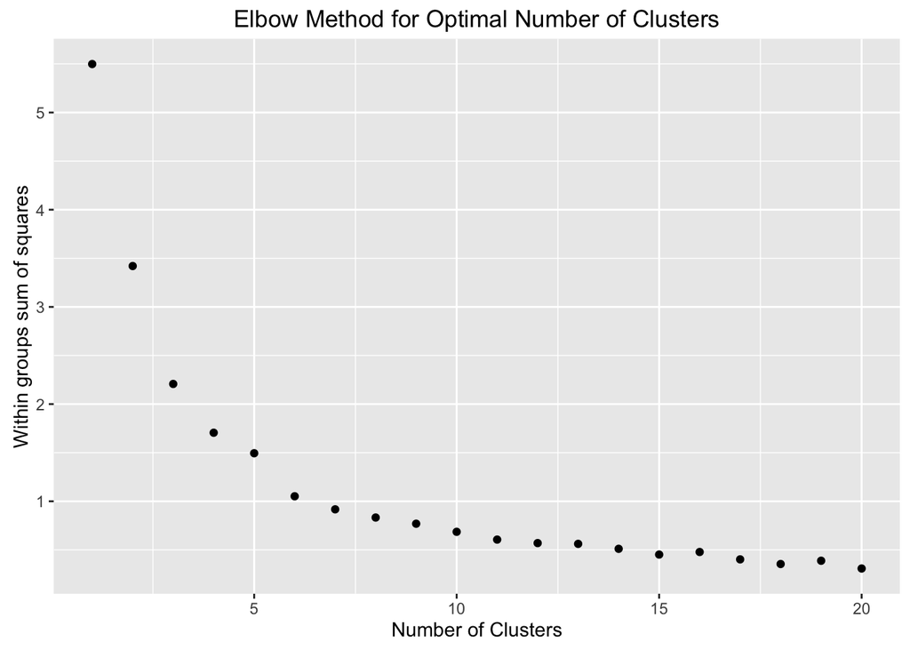

```r
#Load Bangkok coordinates
latlon_bkk <- read.csv('processed/latlon_bkk.csv',row.names = 1)
#Find optimal number of clusters using WSS
wss <- (nrow(latlon_bkk)-1)*sum(apply(latlon_bkk,2,var))
  for (i in 2:20) wss[i] <- sum(kmeans(latlon_bkk,
                                       centers=i)$withinss)
qplot(x=1:20, y=wss, geom='point', xlab="Number of Clusters",
     ylab="Within groups sum of squares",main='Elbow Method for Optimal Number of Clusters')
```

We perform the k-means clustering using 6 centers, and summarize the locations to their respective clusters in `cl_lookup`. Then we join it to `big` using `id`.

```r
#Fit k-means with 6 centers
set.seed(1412)
fit <- kmeans(latlon_bkk,6)
latlon_bkk$loc_cluster <- fit$cluster
latlon_bkk$location <- rownames(latlon_bkk)

#Make cluster lookup table
cl_lookup <-data.frame(loc_cluster=1:6)
cl_lookup$location <- sapply(cl_lookup$loc_cluster,
                        FUN=function(x){latlon_bkk[latlon_bkk$loc_cluster==x,]$location})

#Incorporate clusters to big
cl_assign <- function(x){
    result=character()
    for (i in 1:6){
        if (any(x %in% cl_lookup[i,]$location[[1]])){
            result<-c(result,paste0('cl',i))
        }
    }
    return(result)
}

big$loc_cluster <- sapply(big$location,cl_assign)
```

The location clusters are shown below. We named them loosely according to their corresponding areas: Kaset-Ratchayothin,Ladprao-Ramkamhaeng,Donmuang-Rangsit,Thonburi,Sukhumvit,Downtown.

```r
#Mapping
mapper <- data.frame(location=unlist(big$location))
mapper<-join(mapper,latlon_bkk)
mapper<-mapper[complete.cases(mapper),]

colnames(mapper)<-c('location','LONGITUDE','LATITUDE','loc_cluster')

pal <- colorFactor(c('#F36645','#FFC65D','#7CC8A4','#4DC4DA','#94648E','#404040'), domain = 1:6)
l<-leaflet(mapper) %>%
    #Set bound
    fitBounds(~min(mapper$LONGITUDE), ~min(mapper$LATITUDE),
              ~max(mapper$LONGITUDE), ~max(mapper$LATITUDE)) %>%
    addProviderTiles("CartoDB.Positron") %>%
    addCircleMarkers(popup =mapper$location,stroke=FALSE,color=~pal(mapper$loc_cluster),
    radius=4,fillOpacity =0.5) %>%
    addLegend(position = 'topright',
    colors = c('#F36645','#FFC65D','#7CC8A4','#4DC4DA','#94648E','#404040'),
    labels = c('Kaset-Ratchayothin','Ladprao-Ramkamhaeng','Donmuang-Rangsit','Thonburi','Sukhumvit','Downtown'), opacity = 0.4,
                      title = 'Location clusters')
```

```
## Assuming 'LONGITUDE' and 'LATITUDE' are longitude and latitude, respectively
```

```r
l
```

[interactive chart not shown]

Now we can finally perform the same transformation from list items to features such as we have done with range of services. The `id_loc_cluster` data frame contains such transformation of each prostitute identified by their IDs. This results in 7 new features: 6 for each cluster and 1 for the number of clusters a prostitute belongs to.

```r
#
id_loc_cluster <- subset(big,select=c('id','loc_cluster'))
id_loc_cluster<-id_loc_cluster %>% unnest(loc_cluster) %>% spread(loc_cluster,loc_cluster)
loc_cluster_only <- sapply(id_loc_cluster[,-1],FUN=function(x){!is.na(x)}) %>% as.data.table()
loc_cluster_only$total_loc_cluster <- rowSums(loc_cluster_only)
id_loc_cluster <-cbind(id=id_loc_cluster$id,loc_cluster_only)
```

## Room Types

The last list-items-to-features transformation is for room types. The `id_room` data frame contains such transformation of each prostitute identified by their IDs. This results in 6 new features: 5 for each room type and 1 for the number of room types available for each prostitute.

```r
#id with room
id_room <- subset(big,select=c('id','room'))
id_room<-id_room %>% unnest(room) %>% spread(room,room)
room_only <- sapply(id_room[,-1],FUN=function(x){!is.na(x)}) %>% as.data.table()
room_only$total_room <- rowSums(room_only)
colnames(room_only)<-c('car','hotel','guest_room','curry_room','outdoor','total_room')
id_room <-cbind(id=id_room$id,room_only)
```

# Making the Feature Space

The feature space consists of the following features:

- ID
- Gender
- Age
- Range of service
- Location clusters
- Room types
- Height, weight and BMI
- Breast, waist, and hip measurements as well as breast-waist and hip-waist ratios
- Picture count; number of pictures included in the listing
- Telephone number (exists or not)
- LINE instant messenger (exists or not)
- Email (exists or not)
- Views per day listed; indicates the amount of attention a prostitute gets, used as proxy for revenue
- Price

```r
#Create feature space
features<-data.table(id=big$id)

#Gender
#Translate to English
features$gender <- big$gender
features$gender <- gsub('หญิงแท้','female',features$gender)
features$gender <- gsub('สาวสองผ่าแล้ว','ladyboy_op',features$gender)
features$gender <- gsub('สาวสองยังไม่ผ่า','ladyboy_notop',features$gender)
features$gender <- gsub('ทอม','butch',features$gender)
features$gender <- gsub('ชายแท้','male',features$gender)

#Age
features$age <- big$age

#Range of service
features<-join(features,id_do)

#Location clusters
features<-join(features,id_loc_cluster)

#Room types
features<-join(features,id_room)

#Height, weight and BMI
features$height <- big$height
features$weight <- big$weight
features$bmi <- features$weight/(features$height/100)^2

#Breast, waist, and hip measurements as well as breast-waist and hip-waist ratios
features$breast <- big$breast
features$waist <- big$waist
features$hip <- big$hip
features$bw <- features$breast/features$waist
features$hw <- features$hip/features$waist

#Picture count
features$pic_count <- big$pic_count

#Tel, line, email
features$tel <- !is.na(big$tel)
features$line <- !is.na(big$line)
features$email <- !is.na(big$email)

#Day listed since May 21, 2016
big$td <- sapply(big$submit, function(x){as.numeric(dmy('21-5-2016')-dmy(substr(x,1,10)))})
#Views per day listed
features$vpd <- big$views/big$td

#Price
features$price<- big$price

#save features
saveRDS(features,'processed/features.rds')
```